# Exercise solutions: Section 9.11

Author

Rob J Hyndman and George Athanasopoulos

# fpp3 9.11, Ex7

> Consider `aus_airpassengers`, the total number of passengers (in millions) from Australian air carriers for the period 1970-2011.
> 1. Use `ARIMA()` to find an appropriate ARIMA model. What model was selected. Check that the residuals look like white noise. Plot forecasts for the next 10 periods.

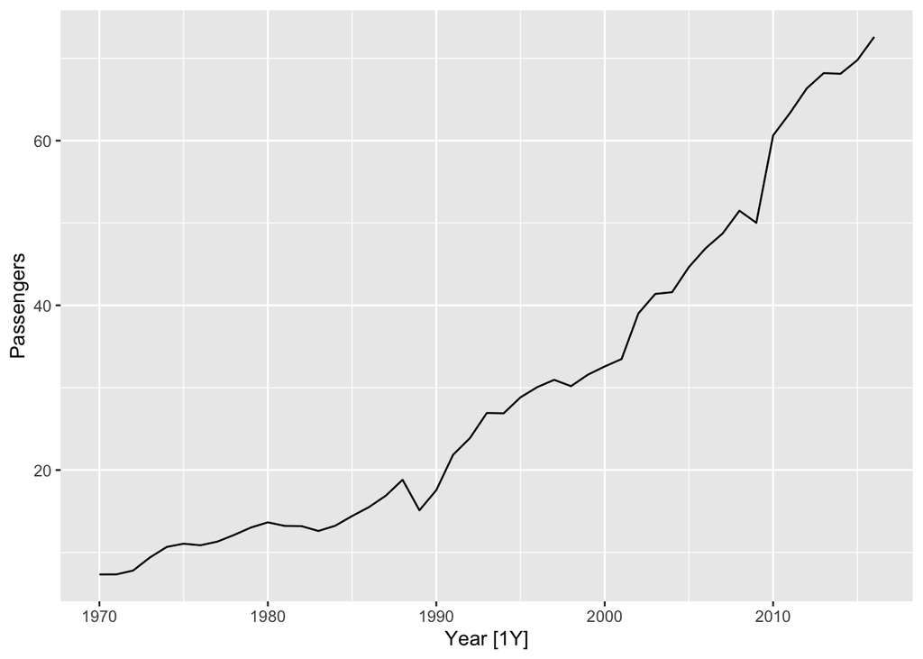

```r
aus_airpassengers |> autoplot(Passengers)
```

```r
fit <- aus_airpassengers |>
  model(arima = ARIMA(Passengers))
report(fit)
```

```
Series: Passengers
Model: ARIMA(0,2,1)

Coefficients:
          ma1
      -0.8963
s.e.   0.0594

sigma^2 estimated as 4.308:  log likelihood=-97.02
AIC=198.04   AICc=198.32   BIC=201.65
```

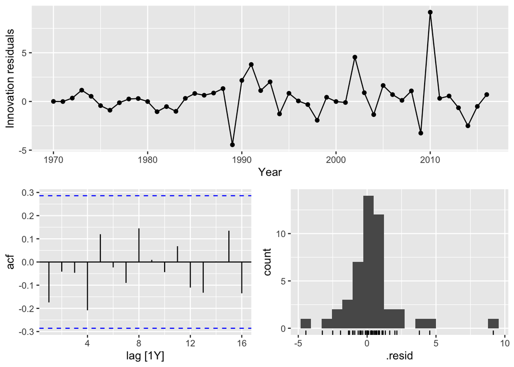

```r
fit |> gg_tsresiduals()
```

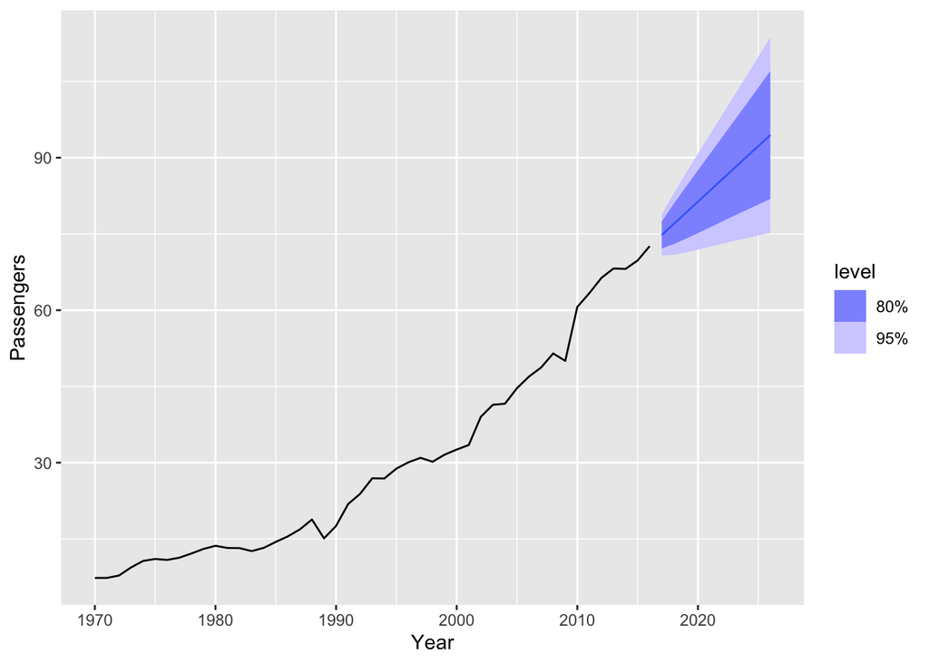

```r
fit |> forecast(h = 10) |> autoplot(aus_airpassengers)
```

> 2. Write the model in terms of the backshift operator.

[output not shown]

$$(1-B)^2y_t = (1+\theta B)\varepsilon_t$$
where $\varepsilon\sim\text{N}(0,\sigma^2)$, $\theta = -0.90$ and $\sigma^2 = 4.31$.

> 3. Plot forecasts from an ARIMA(0,1,0) model with drift and compare these to part a.

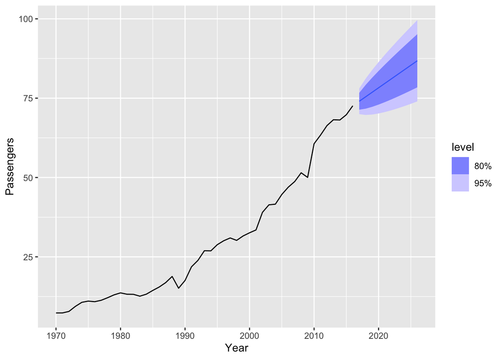

```r
aus_airpassengers |>
  model(arima = ARIMA(Passengers ~ 1 + pdq(0,1,0))) |>
  forecast(h = 10) |>
  autoplot(aus_airpassengers)
```

- Both containing increasing trends, but the ARIMA(0,2,1) model has an implicit trend due to the double-differencing, while the ARIMA(0,1,0) with drift models the trend directly via the trend coefficient.
- The intervals are narrower when there are fewer differences.
> 4. Plot forecasts from an ARIMA(2,1,2) model with drift and compare these to part b. Remove the constant and see what happens.

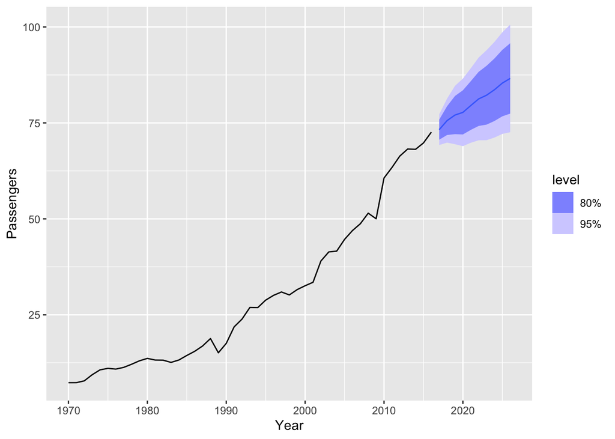

```r
aus_airpassengers |>
  model(arima = ARIMA(Passengers ~ 1 + pdq(2,1,2))) |>
  forecast(h = 10) |>
  autoplot(aus_airpassengers)
```

```r
aus_airpassengers |>
  model(arima = ARIMA(Passengers ~ 0 + pdq(2,1,2)))
```

```
# A mable: 1 x 1
         arima
       <model>
1 <NULL model>
```

- There is little difference between ARIMA(2,1,2) with drift and ARIMA(0,1,0) with drift.
- Removing the constant causes an error because the model cannot be estimated.
> 5. Plot forecasts from an ARIMA(0,2,1) model with a constant. What happens?

```
Warning: Model specification induces a quadratic or higher order polynomial trend.
This is generally discouraged, consider removing the constant or reducing the number of differences.
```

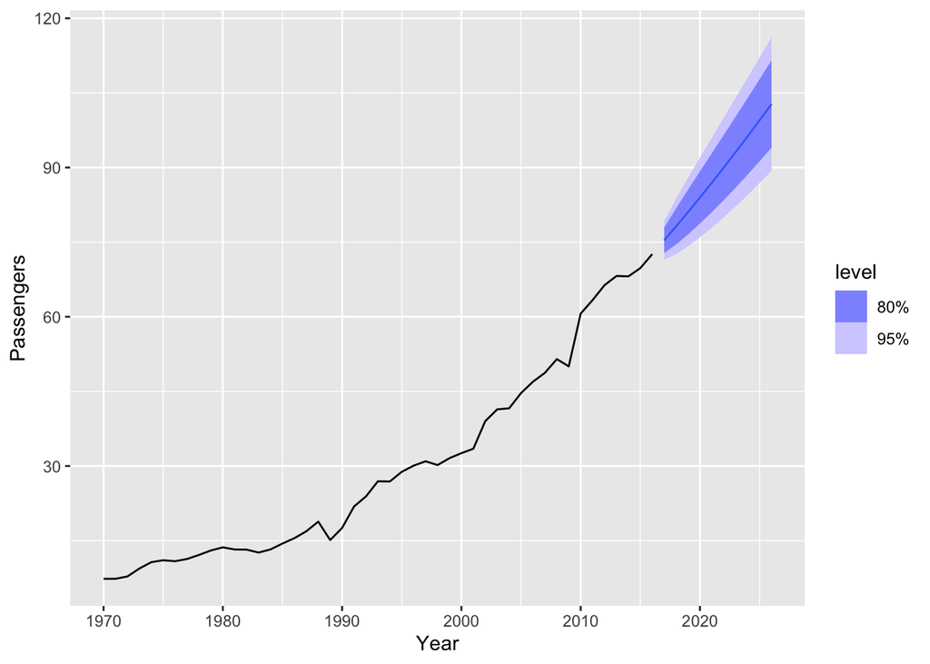

```r
aus_airpassengers |>
  model(arima = ARIMA(Passengers ~ 1 + pdq(0,2,1))) |>
  forecast(h = 10) |>
  autoplot(aus_airpassengers)
```

The forecast trend is now quadratic, and there is a warning that this is generally a bad idea.

# fpp3 9.11, Ex8

> For the United States GDP series (from `global_economy`):
> 1. If necessary, find a suitable Box-Cox transformation for the data;

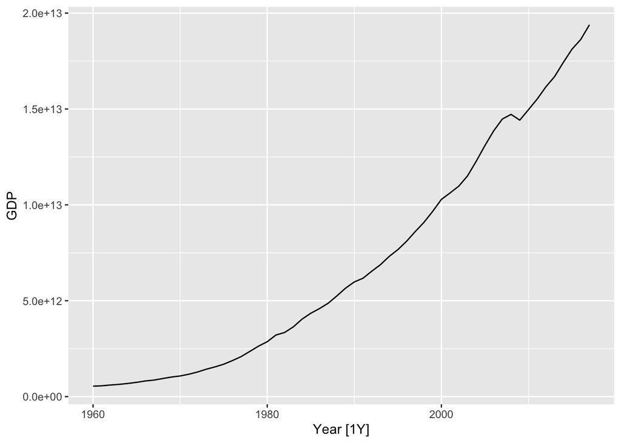

```r
us_economy <- global_economy |>
  filter(Code == "USA")
us_economy |>
  autoplot(GDP)
```

```r
lambda <- us_economy |>
  features(GDP, features = guerrero) |>
  pull(lambda_guerrero)
lambda
```

```
[1] 0.2819443
```

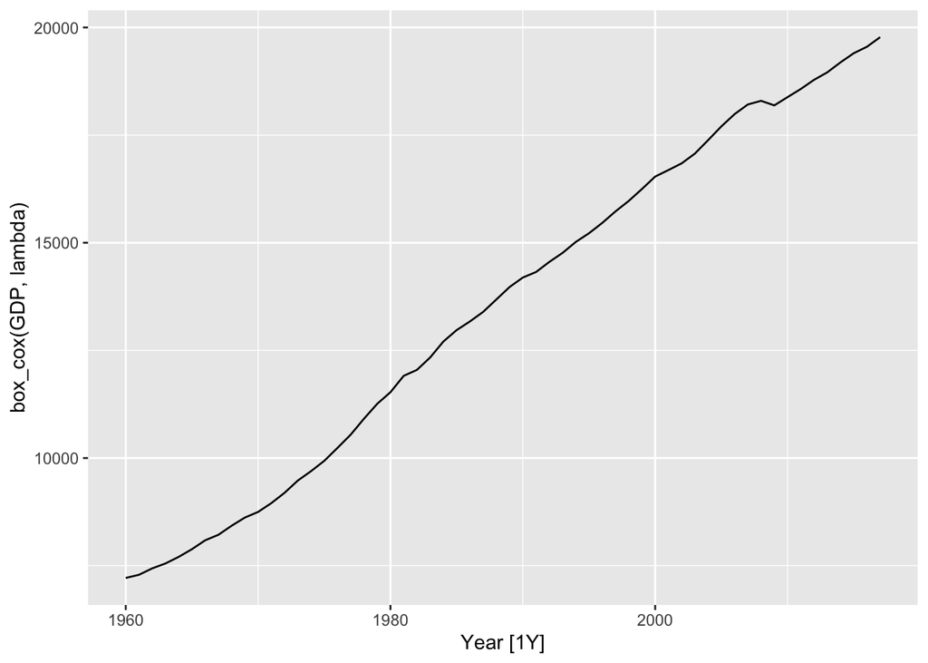

```r
us_economy |>
  autoplot(box_cox(GDP, lambda))
```

It seems that a Box-Cox transformation may be useful here.

> 2. fit a suitable ARIMA model to the transformed data using `ARIMA()`;

```r
fit <- us_economy |>
  model(ARIMA(box_cox(GDP, lambda)))
report(fit)
```

```
Series: GDP
Model: ARIMA(1,1,0) w/ drift
Transformation: box_cox(GDP, lambda)

Coefficients:
         ar1  constant
      0.4586  118.1822
s.e.  0.1198    9.5047

sigma^2 estimated as 5479:  log likelihood=-325.32
AIC=656.65   AICc=657.1   BIC=662.78
```

> 3. try some other plausible models by experimenting with the orders chosen;

```r
fit <- us_economy |>
  model(
    arima010 = ARIMA(box_cox(GDP, lambda) ~ 1 + pdq(0, 1, 0)),
    arima011 = ARIMA(box_cox(GDP, lambda) ~ 1 + pdq(0, 1, 1)),
    arima012 = ARIMA(box_cox(GDP, lambda) ~ 1 + pdq(0, 1, 2)),
    arima013 = ARIMA(box_cox(GDP, lambda) ~ 1 + pdq(0, 1, 3)),
    arima110 = ARIMA(box_cox(GDP, lambda) ~ 1 + pdq(1, 1, 0)),
    arima111 = ARIMA(box_cox(GDP, lambda) ~ 1 + pdq(1, 1, 1)),
    arima112 = ARIMA(box_cox(GDP, lambda) ~ 1 + pdq(1, 1, 2)),
    arima113 = ARIMA(box_cox(GDP, lambda) ~ 1 + pdq(1, 1, 3)),
    arima210 = ARIMA(box_cox(GDP, lambda) ~ 1 + pdq(2, 1, 0)),
    arima211 = ARIMA(box_cox(GDP, lambda) ~ 1 + pdq(2, 1, 1)),
    arima212 = ARIMA(box_cox(GDP, lambda) ~ 1 + pdq(2, 1, 2)),
    arima213 = ARIMA(box_cox(GDP, lambda) ~ 1 + pdq(2, 1, 3)),
    arima310 = ARIMA(box_cox(GDP, lambda) ~ 1 + pdq(3, 1, 0)),
    arima311 = ARIMA(box_cox(GDP, lambda) ~ 1 + pdq(3, 1, 1)),
    arima312 = ARIMA(box_cox(GDP, lambda) ~ 1 + pdq(3, 1, 2)),
    arima313 = ARIMA(box_cox(GDP, lambda) ~ 1 + pdq(3, 1, 3))
  )
```

> 4. choose what you think is the best model and check the residual diagnostics;

```r
fit |>
  glance() |>
  arrange(AICc) |>
  select(.model, AICc)
```

```
# A tibble: 16 × 2
   .model    AICc
   <chr>    <dbl>
 1 arima110  657.
 2 arima011  659.
 3 arima111  659.
 4 arima210  659.
 5 arima012  660.
 6 arima112  661.
 7 arima211  661.
 8 arima310  662.
 9 arima013  662.
10 arima312  663.
11 arima311  664.
12 arima113  664.
13 arima212  664.
14 arima313  665.
15 arima213  666.
16 arima010  668.
```

The best according to the AICc values is the ARIMA(1,1,0) w/ drift model.

```r
best_fit <- us_economy |>
  model(ARIMA(box_cox(GDP, lambda) ~ 1 + pdq(1, 1, 0)))
best_fit |> report()
```

```
Series: GDP
Model: ARIMA(1,1,0) w/ drift
Transformation: box_cox(GDP, lambda)

Coefficients:
         ar1  constant
      0.4586  118.1822
s.e.  0.1198    9.5047

sigma^2 estimated as 5479:  log likelihood=-325.32
AIC=656.65   AICc=657.1   BIC=662.78
```

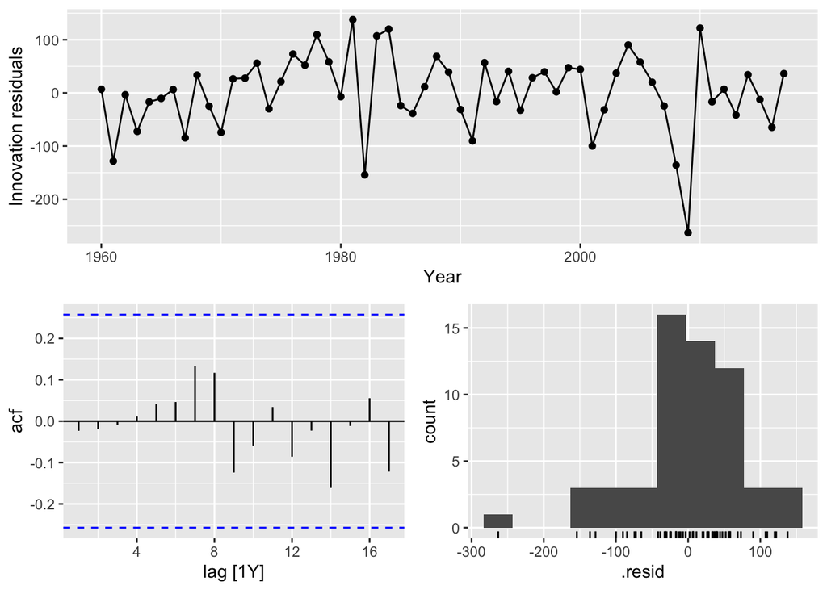

```r
best_fit |> gg_tsresiduals()
```

```r
augment(best_fit) |> features(.innov, ljung_box, dof = 1, lag = 10)
```

```
# A tibble: 1 × 4
  Country       .model                                         lb_stat lb_pvalue
  <fct>         <chr>                                            <dbl>     <dbl>
1 United States ARIMA(box_cox(GDP, lambda) ~ 1 + pdq(1, 1, 0))    3.81     0.923
```

The residuals pass the Ljung-Box test, but the histogram looks like negatively skewed.

> 5. produce forecasts of your fitted model. Do the forecasts look reasonable?

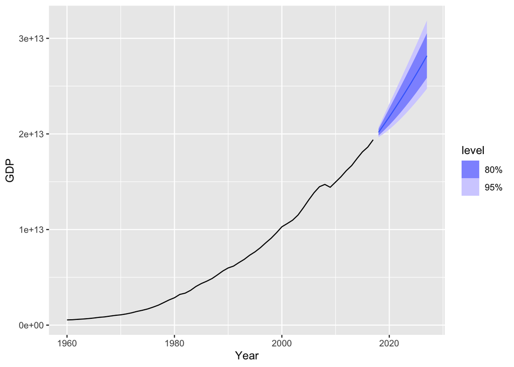

```r
best_fit |>
  forecast(h = 10) |>
  autoplot(us_economy)
```

These look reasonable. Let’s compare a model with no transformation.

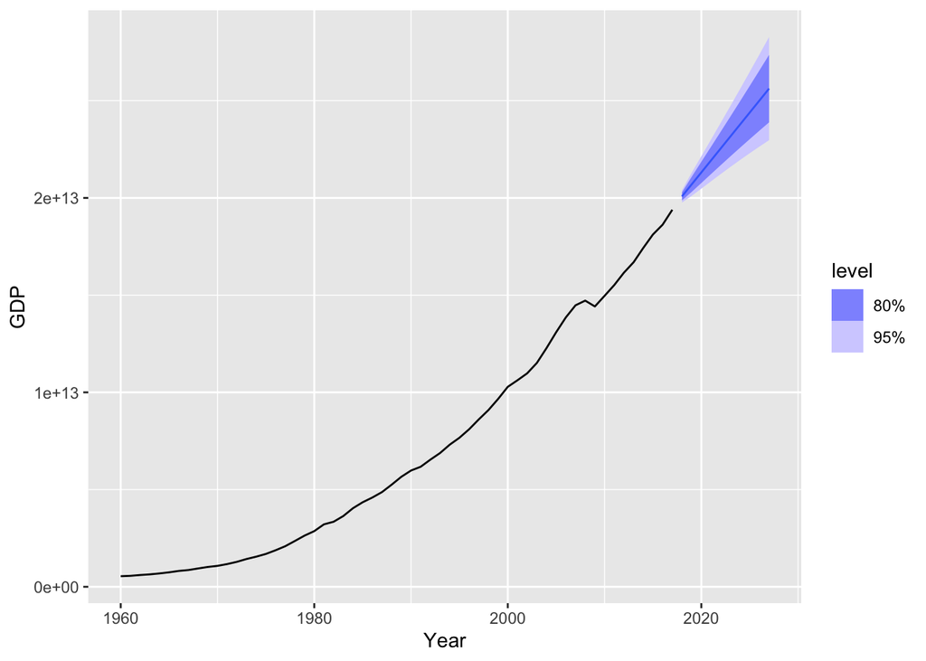

```r
fit1 <- us_economy |> model(ARIMA(GDP))
fit1 |>
  forecast(h = 10) |>
  autoplot(us_economy)
```

Notice the effect of the transformation on the forecasts. Increase the forecast horizon to see what happens. Notice also the width of the prediction intervals.

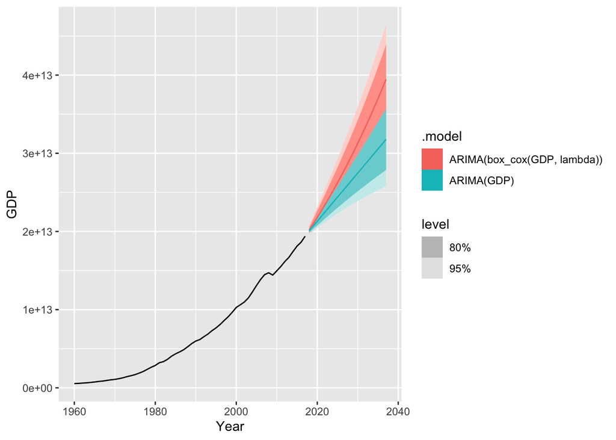

```r
us_economy |>
  model(
    ARIMA(GDP),
    ARIMA(box_cox(GDP, lambda))
  ) |>
  forecast(h = 20) |>
  autoplot(us_economy)
```

> 6. compare the results with what you would obtain using `ETS()` (with no transformation).

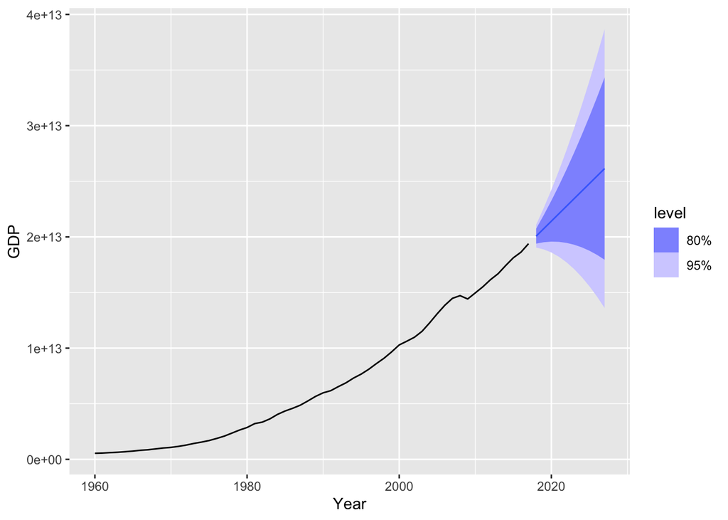

```r
us_economy |>
  model(ETS(GDP)) |>
  forecast(h = 10) |>
  autoplot(us_economy)
```

# fpp3 9.11, Ex15

> Consider the number of Snowshoe Hare furs traded by the Hudson Bay Company between 1845 and 1935 (data set `pelt`).
> 1. Produce a time plot of the time series.

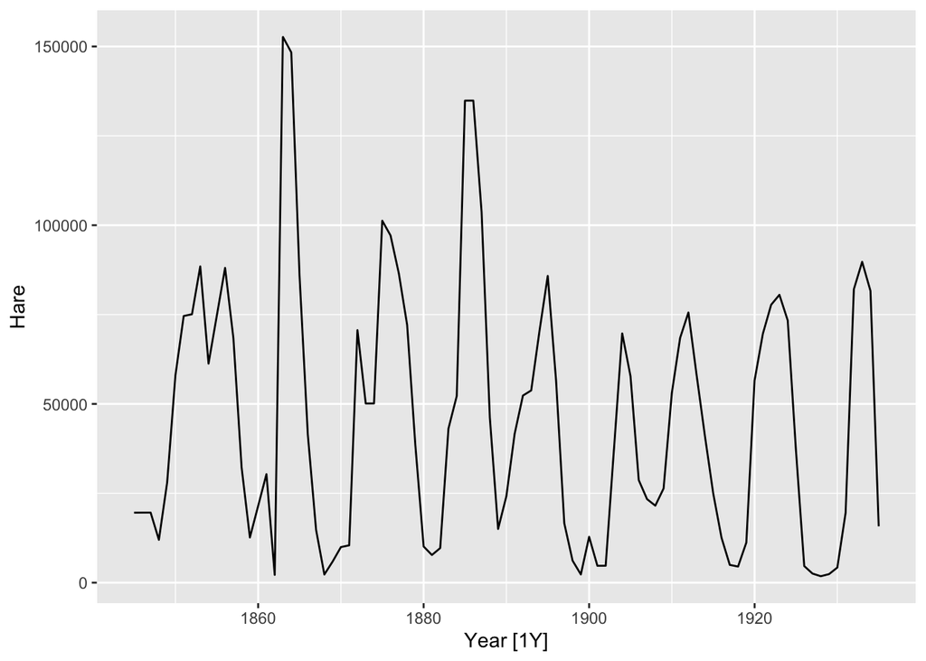

```r
pelt |>
  autoplot(Hare)
```

> 2. Assume you decide to fit the following model:
>    $$y_t = c + \phi_1 y_{t-1} + \phi_2 y_{t-2} + \phi_3 y_{t-3} + \phi_4 y_{t-4} + \varepsilon_t,$$
>    where $\varepsilon_t$ is a white noise series. What sort of ARIMA model is this (i.e., what are $p$, $d$, and $q$)?
- This is an ARIMA(4,0,0), hence $p=4$, $d=0$ and $q=0$.
> 3. By examining the ACF and PACF of the data, explain why this model is appropriate.

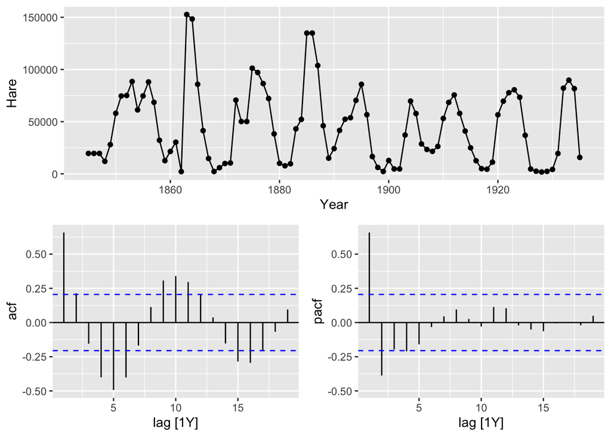

```r
pelt |> gg_tsdisplay(Hare, plot="partial")
```

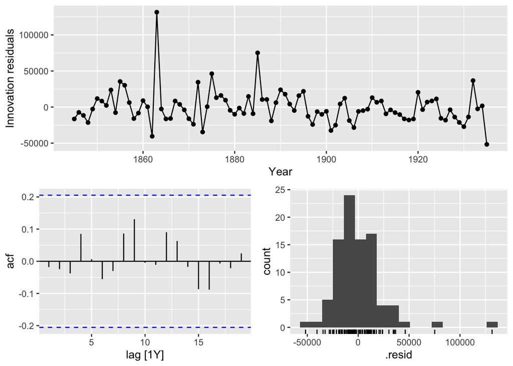

```r
fit <- pelt |> model(AR4 = ARIMA(Hare ~ pdq(4,0,0)))
fit |> gg_tsresiduals()
```

- The significant spike at lag 4 of the PACF indicates an AR(4).
- The residuals from this model are clearly whhite noise.

# fpp3 9.11, Ex16

> The population of Switzerland from 1960 to 2017 is in data set `global_economy`.
> 1. Produce a time plot of the data.

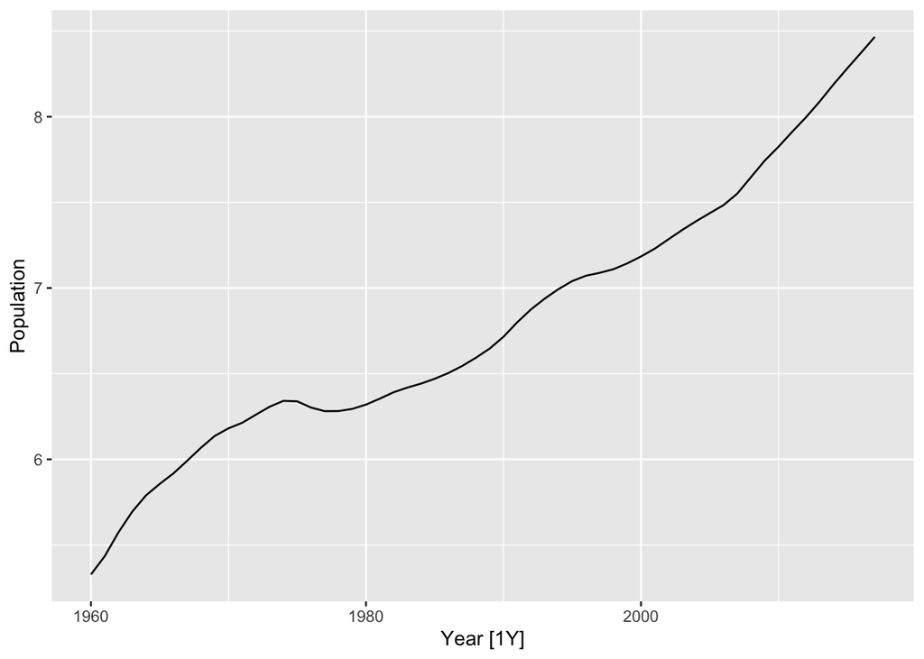

```r
swiss_pop <- global_economy |>
  filter(Country == "Switzerland") |>
  select(Year, Population) |>
  mutate(Population = Population / 1e6)

autoplot(swiss_pop, Population)
```

> 2. You decide to fit the following model to the series:
>    $$y_t = c + y_{t-1} + \phi_1 (y_{t-1} - y_{t-2}) + \phi_2 (y_{t-2} - y_{t-3}) + \phi_3( y_{t-3} - y_{t-4}) + \varepsilon_t$$
>    where $y_t$ is the Population in year $t$ and $\varepsilon_t$ is a white noise series. What sort of ARIMA model is this (i.e., what are $p$, $d$, and $q$)?

This is an ARIMA(3,1,0), hence $p=3$, $d=1$ and $q=0$.

> 3. Explain why this model was chosen using the ACF and PACF of the differenced series.

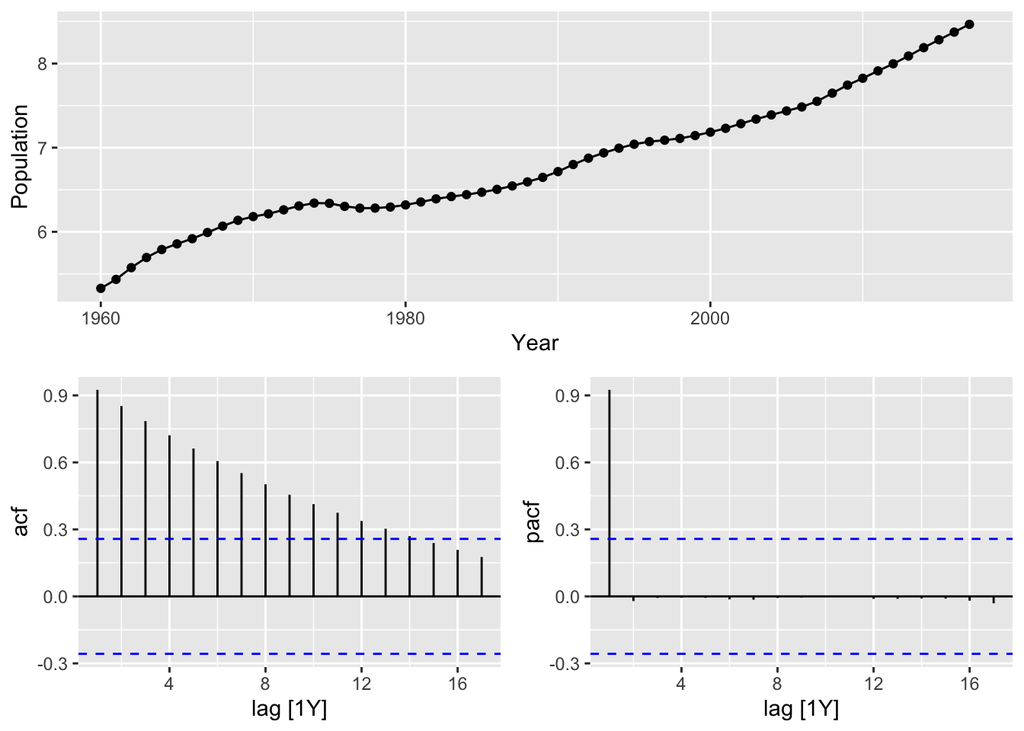

```r
swiss_pop |> gg_tsdisplay(Population, plot="partial")
```

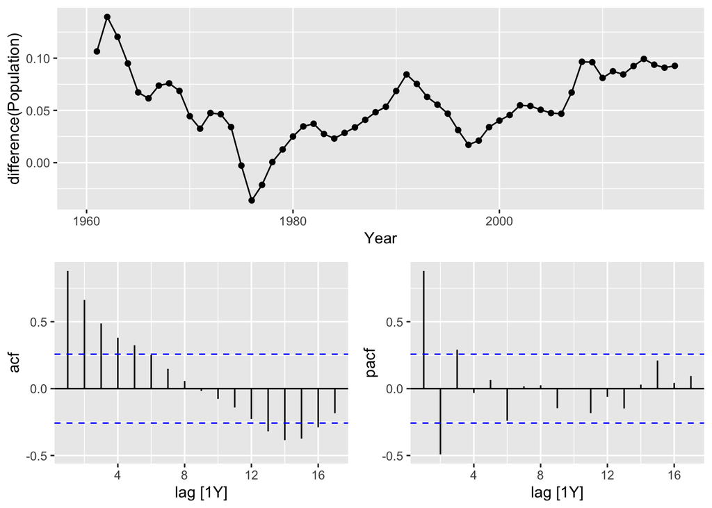

```r
swiss_pop |> gg_tsdisplay(difference(Population), plot="partial")
```

The significant spike at lag 3 in the PACF, coupled with the exponential decay in the ACF, for the differenced series, signals an AR(3) for the differenced series.